# GED16/AO808: Análise de Regressão

AULA02: Prática

Daniel Caixeta, Davi Xie, Fernando Zanchitta, João Marcos de Morais

1o. semestre/2021

### Introdução

“[Infecção hospitalar](https://www.prefeitura.sp.gov.br/cidade/secretarias/saude/vigilancia_em_saude/infeccao_hospitalar/index.php?p=6445) é uma infecção adquirida após a admissão do paciente na unidade hospitalar e pode se manifestar durante a internação ou após a alta. Pela sua gravidade e aumento do tempo de internação do paciente, é causa importante de morbidade e mortalidade, caracterizando-se como problema de saúde pública.”

Os dados disponíveis no arquivo `data/SCENIC.txt` foram coletados pelo CDC (US Center for Disease Control), no âmbito do [Projeto SCENIC](https://doi.org/10.1093/oxfordjournals.aje.a112928). O principal objetivo do projeto era determinar se programas de vigilância e controle foram capazes de reduzir as taxas de infecção hospitalar. Os dados referem-se a uma amostra de 113 hospitais selecionados a partir de um conjunto de 338 hospitais avaliados. Cada linha do conjunto de dados contém uma identificação (1-113) e fornece informação a respeito de 11 variáveis para um único hospital. Os dados apresentados referem-se ao período de 1975-1976.

As 12 variáveis são:

1. `IDnumber`: 1-113 (identificação do hospital)
2. `LengthStay`: período de internação médio de todos os pacientes no hospital (em dias)
3. `Age`: idade média dos pacientes (anos)
4. `InfectRisk`: risco de infecção, calculado como a probabilidade média estimada de contrair infecção no hospital (em %)
5. `CultRatio`: razão do número de culturas realizadas pelo número de pacientes sem sintomas de infecção hospitalar, vezes 100
6. `XrayRatio`: razão do número de raios-X realizados pelo número de pacientes sem sintomas de pneumonia, vezes 100
7. `NBeds`: número médio de leitos do hospital, durante o período avaliado
8. `MedSchool`: afiliação a alguma Escola de Medicina (1=Sim, 2=Não)
9. `Region`: região geográfica (1=NE, 2=NC, 3=S, 4=W)
10. `DailyCensus`: número médio de pacientes no hospital por dia, durante o período avaliado
11. `NNurses`: número médio de enfermeiros no hospital
12. `Facilities`: percentual de 35 serviços providos pelo hospital

Acredita-se que o período médio de internação de um paciente `LengthStay` (variável de resposta) possa ser previsto a partir do risco de infecção hospitalar, bem como outras características do hospital e de procedimentos de rotina realizados.

### Análise Exploratória de Dados

Conduza a análise exploratória da massa de dados `SCENIC`, a fim de compreender suas características principais.

```r
rm(list=ls())

#Carregando os dados em uma tabela
auto <- read.table("data/SCENIC.txt", header = FALSE)

#Verificando a estrutura dos dados e atribuindo os nomes adequados às variáveis
str(auto)
```

```
## 'data.frame':    113 obs. of  12 variables:
##  $ V1 : int  1 2 3 4 5 6 7 8 9 10 ...
##  $ V2 : num  7.13 8.82 8.34 8.95 11.2 ...
##  $ V3 : num  55.7 58.2 56.9 53.7 56.5 50.9 57.8 45.7 48.2 56.3 ...
##  $ V4 : num  4.1 1.6 2.7 5.6 5.7 5.1 4.6 5.4 4.3 6.3 ...
##  $ V5 : num  9 3.8 8.1 18.9 34.5 21.9 16.7 60.5 24.4 29.6 ...
##  $ V6 : num  39.6 51.7 74 122.8 88.9 ...
##  $ V7 : int  279 80 107 147 180 150 186 640 182 85 ...
##  $ V8 : int  2 2 2 2 2 2 2 1 2 2 ...
##  $ V9 : int  4 2 3 4 1 2 3 2 3 1 ...
##  $ V10: int  207 51 82 53 134 147 151 399 130 59 ...
##  $ V11: int  241 52 54 148 151 106 129 360 118 66 ...
##  $ V12: num  60 40 20 40 40 40 40 60 40 40 ...
```

```r
colnames(auto) <- c("IDnumber","LengthStay","Age","InfectRisk","CultRatio","XrayRatio","NBeds","MedSchool","Region","DailyCensus","NNurses","Facilities")
names(auto)
```

```
##  [1] "IDnumber"    "LengthStay"  "Age"         "InfectRisk"  "CultRatio"
##  [6] "XrayRatio"   "NBeds"       "MedSchool"   "Region"      "DailyCensus"
## [11] "NNurses"     "Facilities"
```

```r
#Summary para analisar quais variáveis terão que ser alteradas (de numéricas para categóricas, por exemplo)
summary(auto)
```

```
##     IDnumber     LengthStay          Age          InfectRisk      CultRatio
##  Min.   :  1   Min.   : 6.700   Min.   :38.80   Min.   :1.300   Min.   : 1.60
##  1st Qu.: 29   1st Qu.: 8.340   1st Qu.:50.90   1st Qu.:3.700   1st Qu.: 8.40
##  Median : 57   Median : 9.420   Median :53.20   Median :4.400   Median :14.10
##  Mean   : 57   Mean   : 9.648   Mean   :53.23   Mean   :4.355   Mean   :15.79
##  3rd Qu.: 85   3rd Qu.:10.470   3rd Qu.:56.20   3rd Qu.:5.200   3rd Qu.:20.30
##  Max.   :113   Max.   :19.560   Max.   :65.90   Max.   :7.800   Max.   :60.50
##    XrayRatio          NBeds         MedSchool        Region
##  Min.   : 39.60   Min.   : 29.0   Min.   :1.00   Min.   :1.000
##  1st Qu.: 69.50   1st Qu.:106.0   1st Qu.:2.00   1st Qu.:2.000
##  Median : 82.30   Median :186.0   Median :2.00   Median :2.000
##  Mean   : 81.63   Mean   :252.2   Mean   :1.85   Mean   :2.363
##  3rd Qu.: 94.10   3rd Qu.:312.0   3rd Qu.:2.00   3rd Qu.:3.000
##  Max.   :133.50   Max.   :835.0   Max.   :2.00   Max.   :4.000
##   DailyCensus       NNurses        Facilities
##  Min.   : 20.0   Min.   : 14.0   Min.   : 5.70
##  1st Qu.: 68.0   1st Qu.: 66.0   1st Qu.:31.40
##  Median :143.0   Median :132.0   Median :42.90
##  Mean   :191.4   Mean   :173.2   Mean   :43.16
##  3rd Qu.:252.0   3rd Qu.:218.0   3rd Qu.:54.30
##  Max.   :791.0   Max.   :656.0   Max.   :80.00
```

```r
#codificando corretamente as variáveis necessárias e gerando um novo resumo
auto$IDnumber <- as.factor(auto$IDnumber)
auto$MedSchool <- as.factor(auto$MedSchool)
auto$Region <- as.factor(auto$Region)

summary(auto)
```

```
##     IDnumber     LengthStay          Age          InfectRisk      CultRatio
##  1      :  1   Min.   : 6.700   Min.   :38.80   Min.   :1.300   Min.   : 1.60
##  2      :  1   1st Qu.: 8.340   1st Qu.:50.90   1st Qu.:3.700   1st Qu.: 8.40
##  3      :  1   Median : 9.420   Median :53.20   Median :4.400   Median :14.10
##  4      :  1   Mean   : 9.648   Mean   :53.23   Mean   :4.355   Mean   :15.79
##  5      :  1   3rd Qu.:10.470   3rd Qu.:56.20   3rd Qu.:5.200   3rd Qu.:20.30
##  6      :  1   Max.   :19.560   Max.   :65.90   Max.   :7.800   Max.   :60.50
##  (Other):107
##    XrayRatio          NBeds       MedSchool Region  DailyCensus
##  Min.   : 39.60   Min.   : 29.0   1:17      1:28   Min.   : 20.0
##  1st Qu.: 69.50   1st Qu.:106.0   2:96      2:32   1st Qu.: 68.0
##  Median : 82.30   Median :186.0             3:37   Median :143.0
##  Mean   : 81.63   Mean   :252.2             4:16   Mean   :191.4
##  3rd Qu.: 94.10   3rd Qu.:312.0                    3rd Qu.:252.0
##  Max.   :133.50   Max.   :835.0                    Max.   :791.0
##
##     NNurses        Facilities
##  Min.   : 14.0   Min.   : 5.70
##  1st Qu.: 66.0   1st Qu.:31.40
##  Median :132.0   Median :42.90
##  Mean   :173.2   Mean   :43.16
##  3rd Qu.:218.0   3rd Qu.:54.30
##  Max.   :656.0   Max.   :80.00
##
```

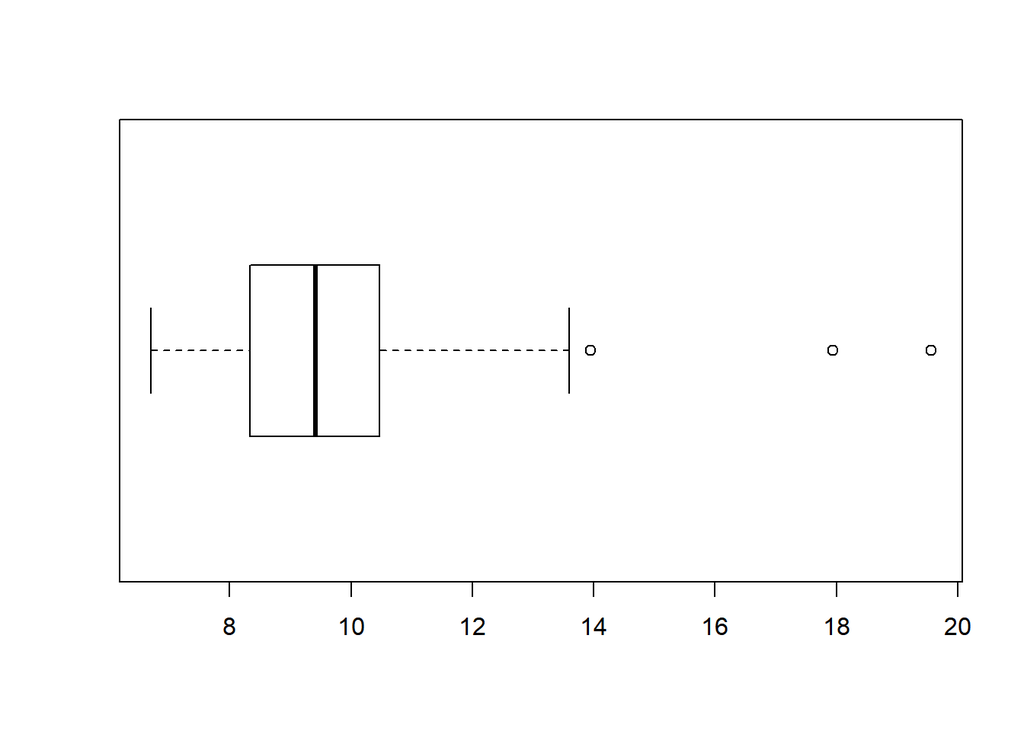

```r
#para utilizar os nomes das variáveis diretamente
attach(auto)

#boxplot e histograma com linha de densidade estimada da variável de resposta
boxplot(LengthStay, horizontal = TRUE)
```

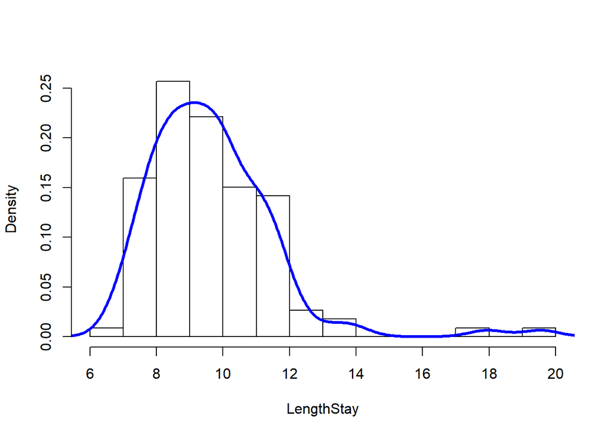

```r
hist(LengthStay, freq = FALSE, breaks = "FD", main = "")
lines(density(LengthStay), col="blue", lwd=3)
```

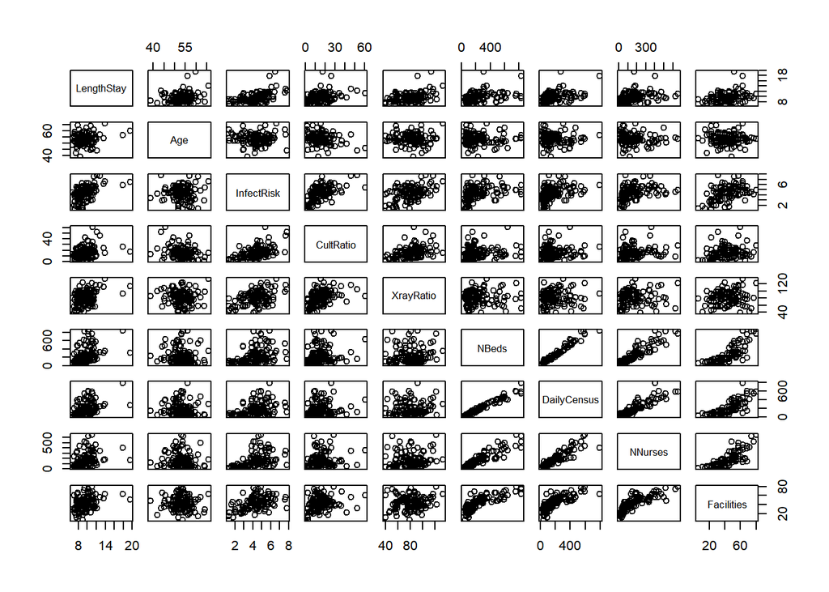

```r
#matriz de gráficos de dispersão
plot(auto[, -c(1,8,9)])
```

```r
#carregar biblioteca para fazer matriz de correlação
library(corrplot)
res <- cor(auto[, -c(1,8,9)])
round(res,2)
```

```
##             LengthStay   Age InfectRisk CultRatio XrayRatio NBeds DailyCensus
## LengthStay        1.00  0.19       0.53      0.33      0.38  0.41        0.47
## Age               0.19  1.00       0.00     -0.23     -0.02 -0.06       -0.05
## InfectRisk        0.53  0.00       1.00      0.56      0.45  0.36        0.38
## CultRatio         0.33 -0.23       0.56      1.00      0.42  0.14        0.14
## XrayRatio         0.38 -0.02       0.45      0.42      1.00  0.05        0.06
## NBeds             0.41 -0.06       0.36      0.14      0.05  1.00        0.98
## DailyCensus       0.47 -0.05       0.38      0.14      0.06  0.98        1.00
## NNurses           0.34 -0.08       0.39      0.20      0.08  0.92        0.91
## Facilities        0.36 -0.04       0.41      0.19      0.11  0.79        0.78
##             NNurses Facilities
## LengthStay     0.34       0.36
## Age           -0.08      -0.04
## InfectRisk     0.39       0.41
## CultRatio      0.20       0.19
## XrayRatio      0.08       0.11
## NBeds          0.92       0.79
## DailyCensus    0.91       0.78
## NNurses        1.00       0.78
## Facilities     0.78       1.00
```

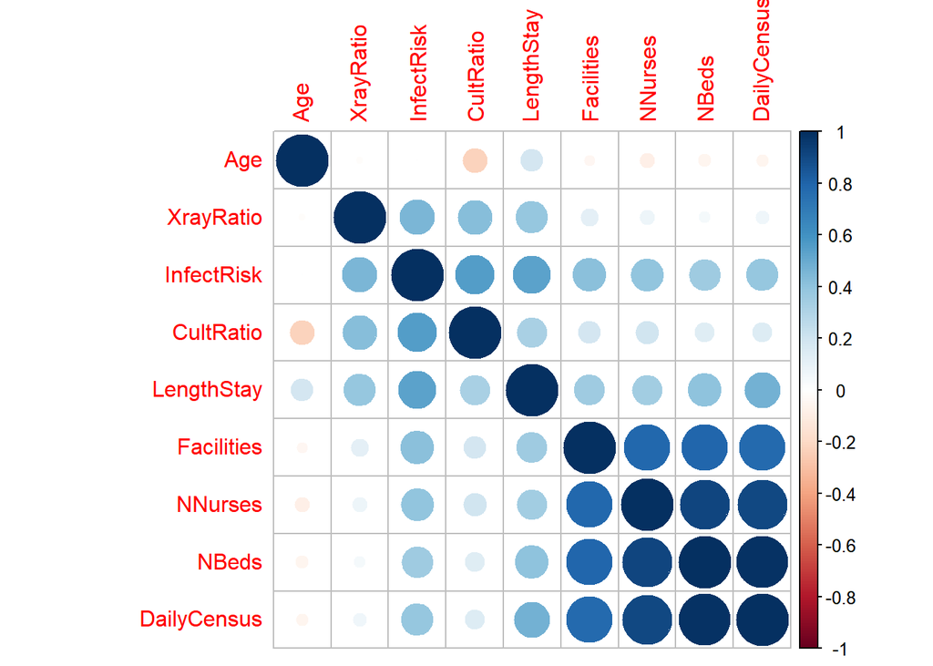

```r
corrplot(res, method = "circle", order = "hclust", sig.level = 0.01, insig = "blank")
```

```r
#A matriz obtida sugere correlação entre algumas variáveis, cujos diagramas de dispersão serão exibidos a seguir.
library(car)
```

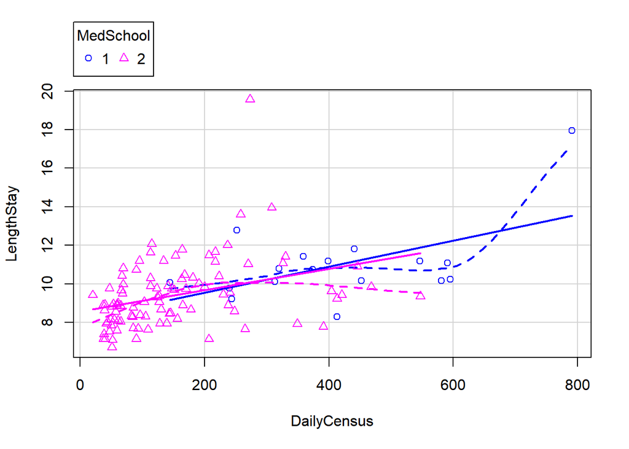

```r
scatterplot(LengthStay ~ DailyCensus|MedSchool, data = auto)
```

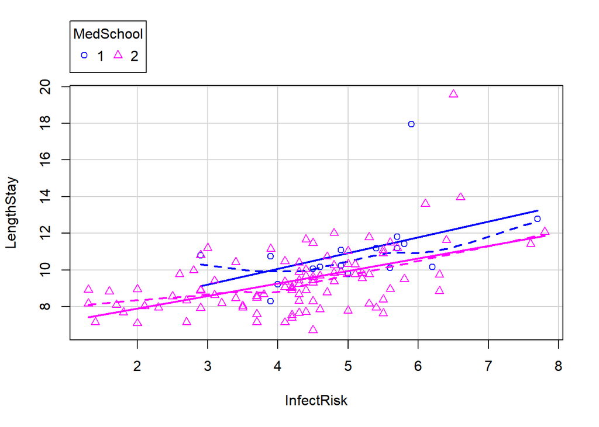

```r
scatterplot(LengthStay ~ InfectRisk|MedSchool, data = auto)
```

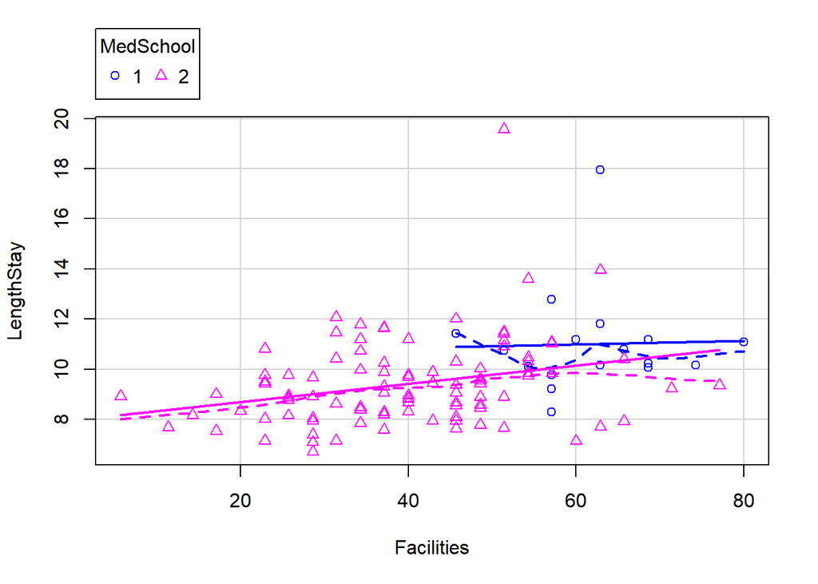

```r
scatterplot(LengthStay ~ Facilities|MedSchool, data = auto)
```

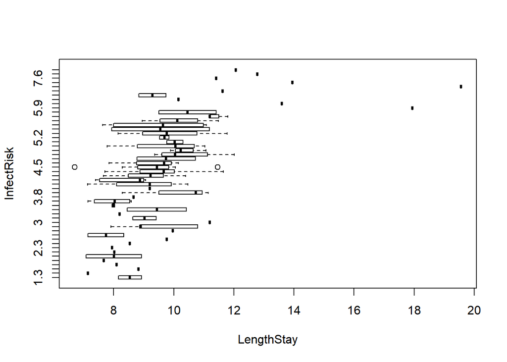

```r
#analisando como a variável de resposta (LengthStay) depende das outras variáveis

#comparando a variável de resposta com outras variáveis

boxplot(LengthStay ~ InfectRisk, horizontal = TRUE)
```

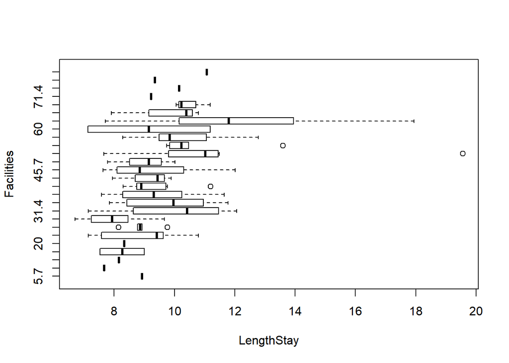

```r
boxplot(LengthStay ~ Facilities, horizontal = TRUE)
```

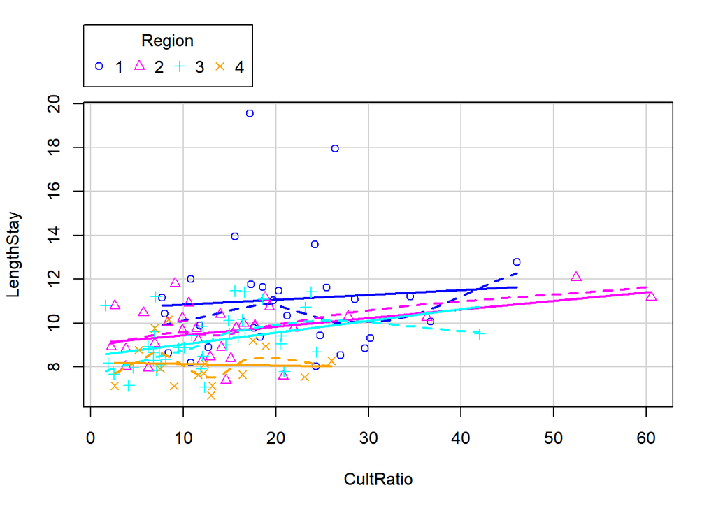

```r
#Diagrama de dispersão condicional para cada região
scatterplot(LengthStay ~ CultRatio|Region, data = auto)
```

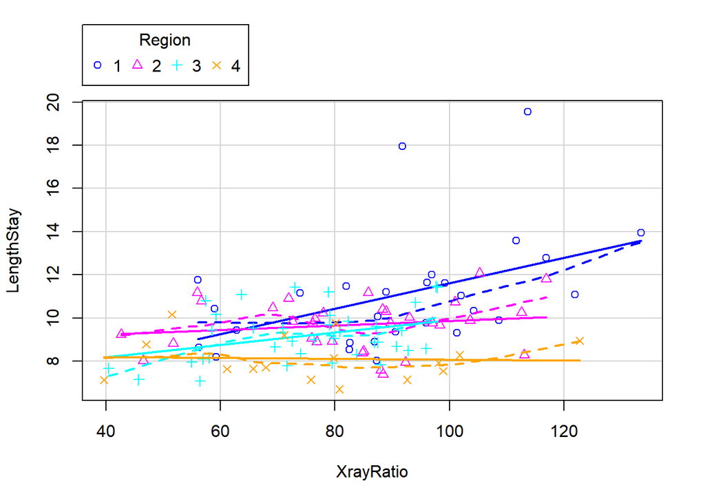

```r
scatterplot(LengthStay ~ XrayRatio|Region, data = auto)
```

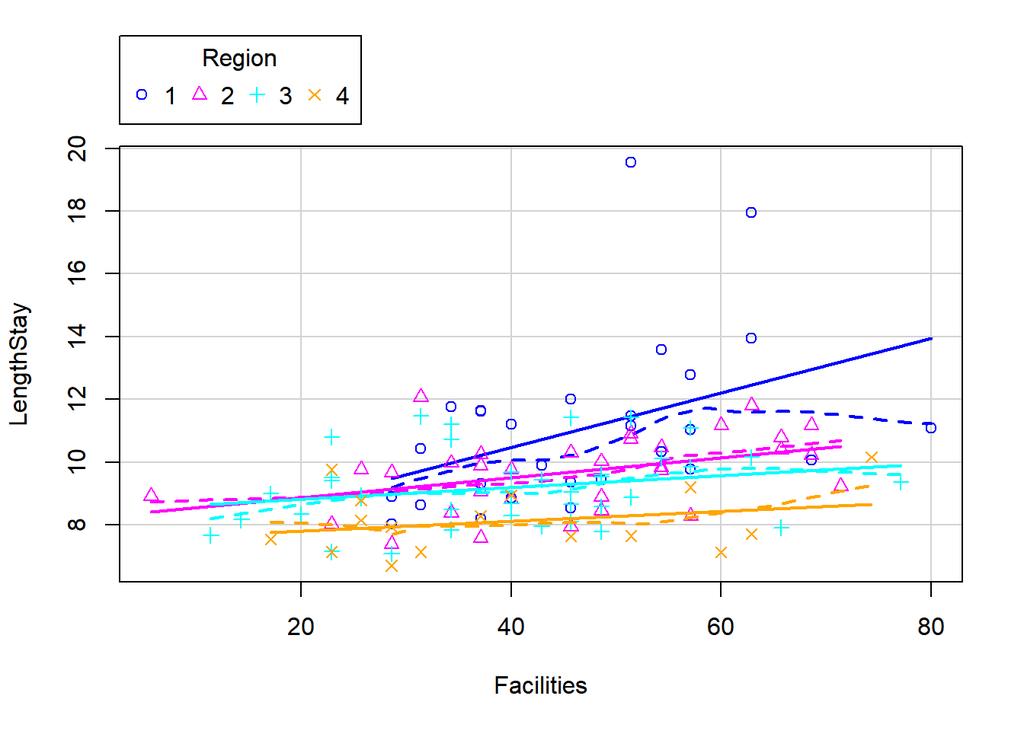

```r
scatterplot(LengthStay ~ Facilities|Region, data = auto)
```

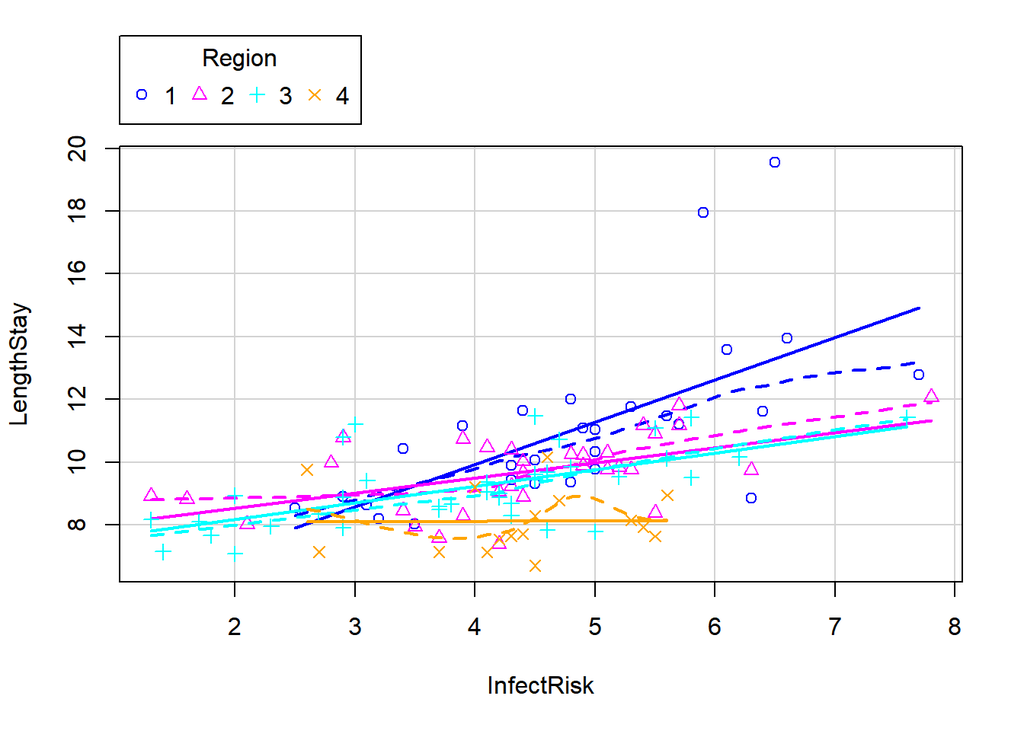

```r
scatterplot(LengthStay ~ InfectRisk|Region, data = auto)
```

```r
#Construção de nova base de dados

data_rls <- data.frame(LengthStay = LengthStay, InfectRisk = InfectRisk,Facilities = Facilities,XrayRatio = XrayRatio )
summary(data_rls)
```

```
##    LengthStay       InfectRisk      Facilities      XrayRatio
##  Min.   : 6.700   Min.   :1.300   Min.   : 5.70   Min.   : 39.60
##  1st Qu.: 8.340   1st Qu.:3.700   1st Qu.:31.40   1st Qu.: 69.50
##  Median : 9.420   Median :4.400   Median :42.90   Median : 82.30
##  Mean   : 9.648   Mean   :4.355   Mean   :43.16   Mean   : 81.63
##  3rd Qu.:10.470   3rd Qu.:5.200   3rd Qu.:54.30   3rd Qu.: 94.10
##  Max.   :19.560   Max.   :7.800   Max.   :80.00   Max.   :133.50
```

```r
# Constroi modelo de regressao linear simples (rls)

#Para InfectRisk

ir_rls <- lm(LengthStay ~ InfectRisk, data = data_rls)
ir_rls
```

```
##
## Call:
## lm(formula = LengthStay ~ InfectRisk, data = data_rls)
##
## Coefficients:
## (Intercept)   InfectRisk
##      6.3368       0.7604
```

```r
summary(ir_rls)
```

```
##
## Call:
## lm(formula = LengthStay ~ InfectRisk, data = data_rls)
##
## Residuals:
##     Min      1Q  Median      3Q     Max
## -3.0587 -0.7776 -0.1487  0.7159  8.2805
##
## Coefficients:
##             Estimate Std. Error t value Pr(>|t|)
## (Intercept)   6.3368     0.5213  12.156  < 2e-16 ***
## InfectRisk    0.7604     0.1144   6.645 1.18e-09 ***
## ---
## Signif. codes:  0 '***' 0.001 '**' 0.01 '*' 0.05 '.' 0.1 ' ' 1
##
## Residual standard error: 1.624 on 111 degrees of freedom
## Multiple R-squared:  0.2846, Adjusted R-squared:  0.2781
## F-statistic: 44.15 on 1 and 111 DF,  p-value: 1.177e-09
```

```r
anova(ir_rls)
```

|  | Df | Sum Sq | Mean Sq | F value | Pr(>F) |
| --- | --- | --- | --- | --- | --- |
| InfectRisk | 1 | 116.4459 | 116.445856 | 44.14978 | 1.176961e-09 |
| Residuals | 111 | 292.7645 | 2.637518 | NA | NA |

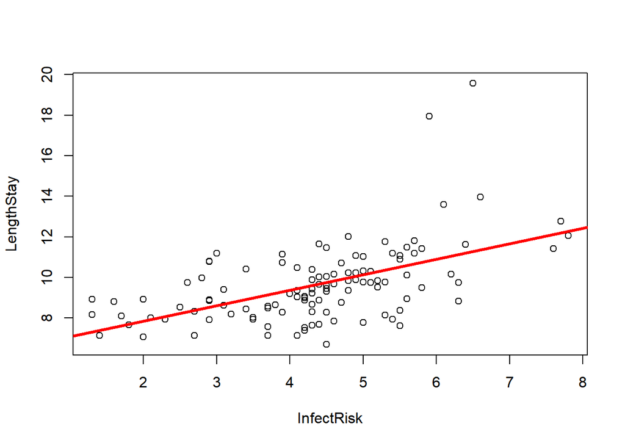

```r
# Adiciona curva de regressao estimada no grafico de dispersao
plot(LengthStay ~InfectRisk)
abline(ir_rls$coef, col=2, lwd=3)
```

```r
#Para Facilities
fa_rls <- lm(LengthStay ~ Facilities, data = data_rls)
fa_rls
```

```
##
## Call:
## lm(formula = LengthStay ~ Facilities, data = data_rls)
##
## Coefficients:
## (Intercept)   Facilities
##     7.71877      0.04471
```

```r
summary(fa_rls)
```

```
##
## Call:
## lm(formula = LengthStay ~ Facilities, data = data_rls)
##
## Residuals:
##     Min      1Q  Median      3Q     Max
## -3.2712 -1.0716 -0.2816  0.7584  9.5433
##
## Coefficients:
##             Estimate Std. Error t value Pr(>|t|)
## (Intercept)  7.71877    0.51020  15.129  < 2e-16 ***
## Facilities   0.04471    0.01116   4.008 0.000111 ***
## ---
## Signif. codes:  0 '***' 0.001 '**' 0.01 '*' 0.05 '.' 0.1 ' ' 1
##
## Residual standard error: 1.795 on 111 degrees of freedom
## Multiple R-squared:  0.1264, Adjusted R-squared:  0.1185
## F-statistic: 16.06 on 1 and 111 DF,  p-value: 0.0001113
```

```r
anova(fa_rls)
```

|  | Df | Sum Sq | Mean Sq | F value | Pr(>F) |
| --- | --- | --- | --- | --- | --- |
| Facilities | 1 | 51.72714 | 51.72714 | 16.06149 | 0.000111339 |
| Residuals | 111 | 357.48324 | 3.22057 | NA | NA |

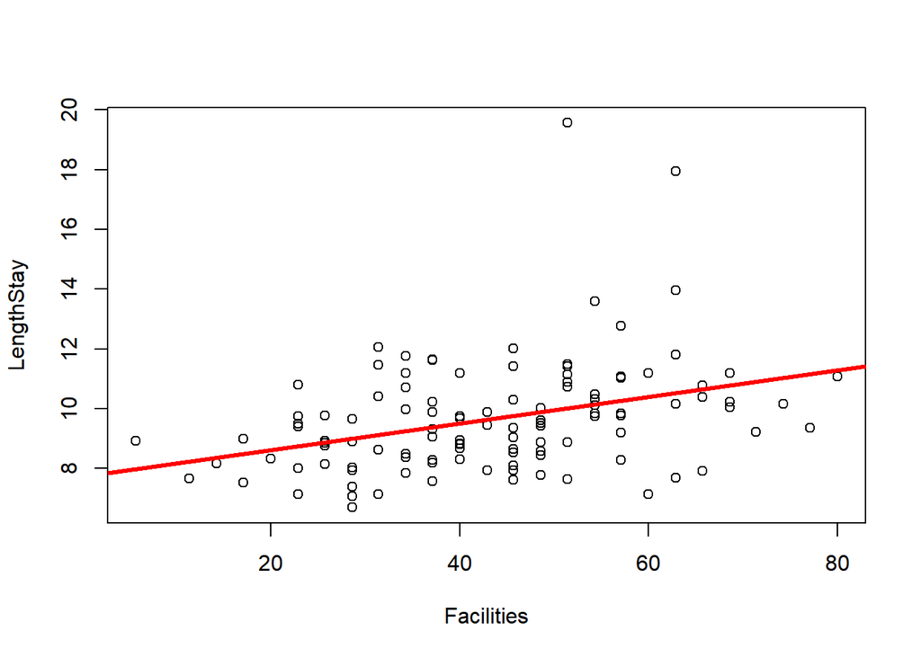

```r
# Adiciona curva de regressao estimada no grafico de dispersao
plot(LengthStay ~Facilities)
abline(fa_rls$coef, col=2, lwd=3)
```

```r
#Para XrayRatio
#Para Facilities
xr_rls <- lm(LengthStay ~ XrayRatio, data = data_rls)
xr_rls
```

```
##
## Call:
## lm(formula = LengthStay ~ XrayRatio, data = data_rls)
##
## Coefficients:
## (Intercept)    XrayRatio
##     6.56637      0.03776
```

```r
summary(xr_rls)
```

```
##
## Call:
## lm(formula = LengthStay ~ XrayRatio, data = data_rls)
##
## Residuals:
##     Min      1Q  Median      3Q     Max
## -2.9226 -1.0810 -0.2708  0.8200  8.7008
##
## Coefficients:
##             Estimate Std. Error t value Pr(>|t|)
## (Intercept) 6.566373   0.726094   9.043 5.67e-15 ***
## XrayRatio   0.037756   0.008657   4.361 2.91e-05 ***
## ---
## Signif. codes:  0 '***' 0.001 '**' 0.01 '*' 0.05 '.' 0.1 ' ' 1
##
## Residual standard error: 1.774 on 111 degrees of freedom
## Multiple R-squared:  0.1463, Adjusted R-squared:  0.1386
## F-statistic: 19.02 on 1 and 111 DF,  p-value: 2.906e-05
```

```r
anova(xr_rls)
```

|  | Df | Sum Sq | Mean Sq | F value | Pr(>F) |
| --- | --- | --- | --- | --- | --- |
| XrayRatio | 1 | 59.86438 | 59.864380 | 19.0211 | 2.905559e-05 |
| Residuals | 111 | 349.34600 | 3.147261 | NA | NA |

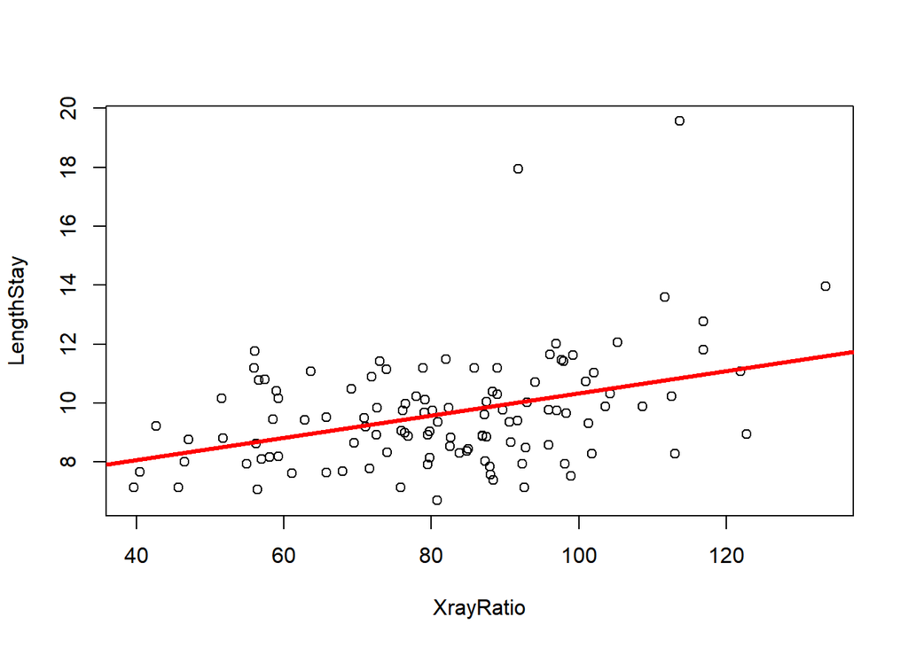

```r
# Adiciona curva de regressao estimada no grafico de dispersao
plot(LengthStay ~XrayRatio)
abline(xr_rls$coef, col=2, lwd=3)
```

```r
#MSE
#os valores de MSE encontrados:
anova(ir_rls)[1,"Mean Sq"]
```

```
## [1] 116.4459
```

```r
anova(fa_rls)[1,"Mean Sq"]
```

```
## [1] 51.72714
```

```r
anova(xr_rls)[1,"Mean Sq"]
```

```
## [1] 59.86438
```

Analisando os valores de R^2, nenhuma variavél possui contribuição satisfatória para explicar o LengthStay, entretanto a com melhor coeficiente de determinação é o InfectRisk.

```r
data_rls <- data.frame(LengthStay = LengthStay, InfectRisk = InfectRisk, Region = Region)
summary(data_rls)
```

```
##    LengthStay       InfectRisk    Region
##  Min.   : 6.700   Min.   :1.300   1:28
##  1st Qu.: 8.340   1st Qu.:3.700   2:32
##  Median : 9.420   Median :4.400   3:37
##  Mean   : 9.648   Mean   :4.355   4:16
##  3rd Qu.:10.470   3rd Qu.:5.200
##  Max.   :19.560   Max.   :7.800
```

```r
attach(data_rls)
```

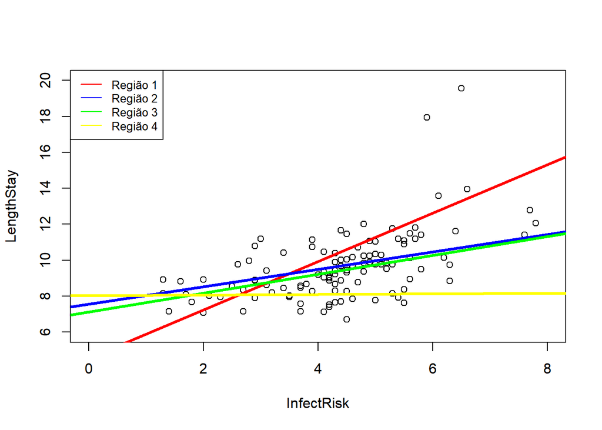

```r
datareg1 <- subset(data_rls, Region == 1)
datareg2 <- subset(data_rls, Region == 2)
datareg3 <- subset(data_rls, Region == 3)
datareg4 <- subset(data_rls, Region == 4)

auto_rls1 <-lm(datareg1$LengthStay ~ datareg1$InfectRisk)
auto_rls2 <-lm(datareg2$LengthStay ~ datareg2$InfectRisk)
auto_rls3 <-lm(datareg3$LengthStay ~ datareg3$InfectRisk)
auto_rls4 <-lm(datareg4$LengthStay ~ datareg4$InfectRisk)
plot(LengthStay ~ InfectRisk,  xlim = c(0,8), ylim = c(6,20) )
legend("topleft", legend = c("Região 1","Região 2", "Região 3", "Região 4"), col = c("red", "blue", "green", "yellow"), lty = 1, cex = 0.8)
abline(auto_rls1, col="red", lwd=3)
abline(auto_rls2, col="blue", lwd=3)
abline(auto_rls3, col="green", lwd=3)
abline(auto_rls4, col="yellow", lwd=3)
```

Vamos separar os gráficos em 4, para poder fazer uma análise mais precisa.

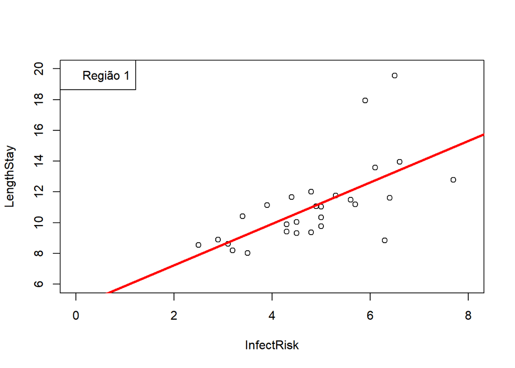

```r
plot(datareg1$LengthStay ~ datareg1$InfectRisk, xlim = c(0,8), ylim = c(6,20), xlab = "InfectRisk", ylab = "LengthStay")
legend("topleft", legend = c("Região 1"))
abline(auto_rls1, col="red", lwd=3)
```

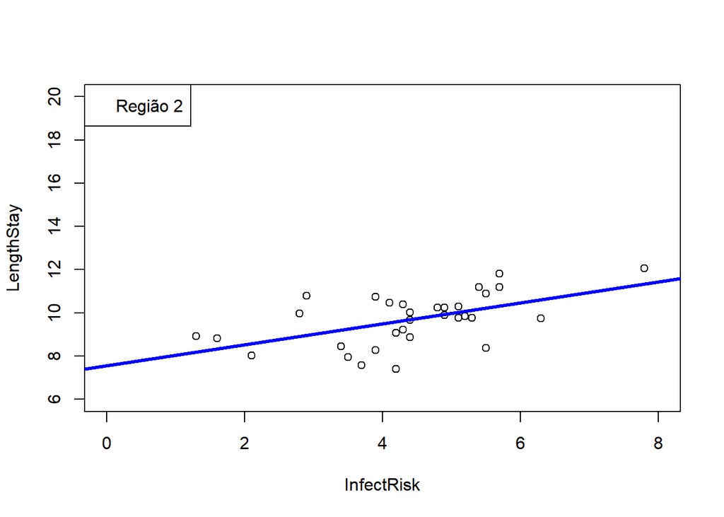

```r
plot(datareg2$LengthStay ~ datareg2$InfectRisk, xlim = c(0,8), ylim = c(6,20), xlab = "InfectRisk", ylab = "LengthStay" )
legend("topleft", legend = c("Região 2"))
abline(auto_rls2, col="blue", lwd=3)
```

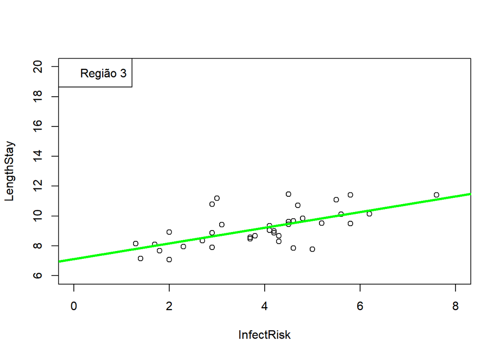

```r
plot(datareg3$LengthStay ~ datareg3$InfectRisk, xlim = c(0,8), ylim = c(6,20), xlab = "InfectRisk", ylab = "LengthStay" )
legend("topleft", legend = c("Região 3"))
abline(auto_rls3, col="green", lwd=3)
```

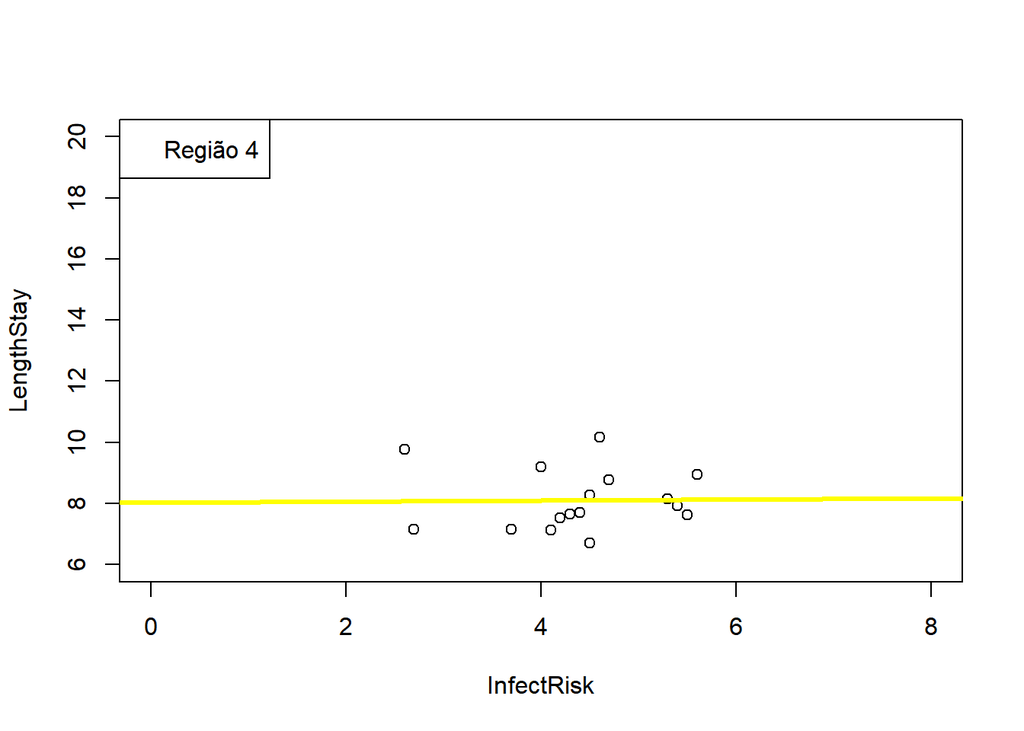

```r
plot(datareg4$LengthStay ~ datareg4$InfectRisk, xlim = c(0,8), ylim = c(6,20), xlab = "InfectRisk", ylab = "LengthStay" )
legend("topleft", legend = c("Região 4"))
abline(auto_rls4, col="yellow", lwd=3)
```

De acordo com o primeiro gráfico, as funções de regressão foram semelhantes nas regiões 2 e 3 e, nas regiões 1 e 4, foram diferentes entre si e das demais. Analisando as retas, sugere-se que o InfectRisk não tem impacto no LengthStay para a região 4, enquanto que, para a região 1, a relação é direta, visto que o aumento do InfectRisk faz crescer o valor de LengthStay; já para as regiões 2 e 3, nota-se uma possível relação, mas mais sutil que para a Região 1. Contudo, é necessário se atentar a outros fatores relevantes para garantir a qualidade da regressão e a veracidade da correlação das variáveis.Tal análise será feita a seguir.

```r
anova(auto_rls1)[1,"Mean Sq"]
```

```
## [1] 79.24452
```

```r
anova(auto_rls2)[1,"Mean Sq"]
```

```
## [1] 12.97975
```

```r
anova(auto_rls3)[1,"Mean Sq"]
```

```
## [1] 21.12862
```

```r
anova(auto_rls4)[1,"Mean Sq"]
```

```
## [1] 0.0034406
```

Faremos “summary” para cada subconjunto de dados respectivo a cada Região para conferir os valores dois coeficientes em relação aos intervalos de confiança.

```r
summary(auto_rls1)
```

```
##
## Call:
## lm(formula = datareg1$LengthStay ~ datareg1$InfectRisk)
##
## Residuals:
##     Min      1Q  Median      3Q     Max
## -4.1887 -1.0713 -0.3449  0.6822  6.2617
##
## Coefficients:
##                     Estimate Std. Error t value Pr(>|t|)
## (Intercept)           4.5379     1.5852   2.863 0.008193 **
## datareg1$InfectRisk   1.3477     0.3159   4.267 0.000233 ***
## ---
## Signif. codes:  0 '***' 0.001 '**' 0.01 '*' 0.05 '.' 0.1 ' ' 1
##
## Residual standard error: 2.086 on 26 degrees of freedom
## Multiple R-squared:  0.4118, Adjusted R-squared:  0.3892
## F-statistic:  18.2 on 1 and 26 DF,  p-value: 0.0002326
```

```r
summary(auto_rls2)
```

```
##
## Call:
## lm(formula = datareg2$LengthStay ~ datareg2$InfectRisk)
##
## Residuals:
##     Min      1Q  Median      3Q     Max
## -2.1998 -0.6047  0.1244  0.7435  1.8283
##
## Coefficients:
##                     Estimate Std. Error t value Pr(>|t|)
## (Intercept)           7.5605     0.6267  12.063 4.89e-13 ***
## datareg2$InfectRisk   0.4832     0.1366   3.536  0.00134 **
## ---
## Signif. codes:  0 '***' 0.001 '**' 0.01 '*' 0.05 '.' 0.1 ' ' 1
##
## Residual standard error: 1.019 on 30 degrees of freedom
## Multiple R-squared:  0.2942, Adjusted R-squared:  0.2707
## F-statistic: 12.51 on 1 and 30 DF,  p-value: 0.001341
```

```r
summary(auto_rls3)
```

```
##
## Call:
## lm(formula = datareg3$LengthStay ~ datareg3$InfectRisk)
##
## Residuals:
##     Min      1Q  Median      3Q     Max
## -1.9748 -0.4921 -0.2071  0.2900  2.4954
##
## Coefficients:
##                     Estimate Std. Error t value Pr(>|t|)
## (Intercept)           7.1293     0.4632  15.393  < 2e-16 ***
## datareg3$InfectRisk   0.5251     0.1107   4.742 3.49e-05 ***
## ---
## Signif. codes:  0 '***' 0.001 '**' 0.01 '*' 0.05 '.' 0.1 ' ' 1
##
## Residual standard error: 0.9694 on 35 degrees of freedom
## Multiple R-squared:  0.3911, Adjusted R-squared:  0.3737
## F-statistic: 22.48 on 1 and 35 DF,  p-value: 3.494e-05
```

```r
summary(auto_rls4)
```

```
##
## Call:
## lm(formula = datareg4$LengthStay ~ datareg4$InfectRisk)
##
## Residuals:
##     Min      1Q  Median      3Q     Max
## -1.4158 -0.6716 -0.3077  0.6918  2.0425
##
## Coefficients:
##                     Estimate Std. Error t value Pr(>|t|)
## (Intercept)          8.03805    1.36481   5.889 3.94e-05 ***
## datareg4$InfectRisk  0.01728    0.30583   0.056    0.956
## ---
## Signif. codes:  0 '***' 0.001 '**' 0.01 '*' 0.05 '.' 0.1 ' ' 1
##
## Residual standard error: 1.038 on 14 degrees of freedom
## Multiple R-squared:  0.0002279,  Adjusted R-squared:  -0.07118
## F-statistic: 0.003192 on 1 and 14 DF,  p-value: 0.9557
```

```r
confint.lm(auto_rls1, level=0.95)
```

```
##                         2.5 %   97.5 %
## (Intercept)         1.2794501 7.796392
## datareg1$InfectRisk 0.6984451 1.997047
```

```r
confint.lm(auto_rls2, level=0.95)
```

```
##                         2.5 %    97.5 %
## (Intercept)         6.2805261 8.8404863
## datareg2$InfectRisk 0.2041384 0.7622031
```

```r
confint.lm(auto_rls3, level=0.95)
```

```
##                         2.5 %   97.5 %
## (Intercept)         6.1890595 8.069615
## datareg3$InfectRisk 0.3002664 0.749899
```

```r
confint.lm(auto_rls4, level=0.95)
```

```
##                          2.5 %     97.5 %
## (Intercept)          5.1108117 10.9652846
## datareg4$InfectRisk -0.6386564  0.6732136
```

```r
#criação de novos lm para que a criação dos intervalos de confiança funcione
auto_reg1 <- lm(LengthStay ~ InfectRisk, data = datareg1)
auto_reg2 <- lm(LengthStay ~ InfectRisk, data = datareg2)
auto_reg3 <- lm(LengthStay ~ InfectRisk, data = datareg3)
auto_reg4 <- lm(LengthStay ~ InfectRisk, data = datareg4)

Xc1 <- data.frame(InfectRisk = 5)
predict.lm(auto_reg1, newdata=Xc1, interval="confidence", level = 0.95)
```

```
##        fit      lwr      upr
## 1 11.27665 10.46114 12.09216
```

```r
Xc2 <- data.frame(InfectRisk = 5)
predict.lm(auto_reg2, newdata=Xc2, interval="confidence", level = 0.95)
```

```
##       fit      lwr     upr
## 1 9.97636 9.571522 10.3812
```

```r
Xc3 <- data.frame(InfectRisk = 5)
predict.lm(auto_reg3, newdata=Xc3, interval="confidence", level = 0.95)
```

```
##        fit     lwr      upr
## 1 9.754751 9.35118 10.15832
```

```r
Xc4 <- data.frame(InfectRisk = 5)
predict.lm(auto_reg4, newdata=Xc4, interval="confidence", level = 0.95)
```

```
##        fit      lwr      upr
## 1 8.124441 7.435514 8.813368
```

Concluímos que com 95% de confiança que, com ‘InfectRisk = 5’, na:

Região 1, o valor de LengthStay está no intervalo de 10.46114 a 12.09216 dias;

Região 2, o valor de LengthStay está no intervalo de 9.571522 a 10.3812 dias;

Região 3, o valor de LengthStay está no intervalo de 9.35118 a 10.15832 dias;

Região 4, o valor de LengthStay está no intervalo de 7.435514 a 8.813368 dias.

```r
predict.lm(auto_reg1, newdata = Xc1, interval = "prediction", level = 0.95)
```

```
##        fit      lwr      upr
## 1 11.27665 6.911133 15.64217
```

```r
predict.lm(auto_reg2, newdata = Xc2, interval = "prediction", level = 0.95)
```

```
##       fit      lwr      upr
## 1 9.97636 7.856747 12.09597
```

```r
predict.lm(auto_reg3, newdata = Xc3, interval = "prediction", level = 0.95)
```

```
##        fit      lwr      upr
## 1 9.754751 7.745751 11.76375
```

```r
predict.lm(auto_reg4, newdata = Xc4, interval = "prediction", level = 0.95)
```

```
##        fit      lwr      upr
## 1 8.124441 5.793563 10.45532
```

Concluímos que com 95% de confiança que, com ‘InfectRisk = 5’, na:

Região 1, o LengthStay esperado para um novo hospital está eno intervalo de 6.911133 a 15.64217 dias;

Região 2, o LengthStay esperado para um novo hospital está eno intervalo de 7.856747 a 12.095977 dias;

Região 3, o LengthStay esperado para um novo hospital está eno intervalo de 7.745751 a 11.76375 dias;

Região 4, o LengthStay esperado para um novo hospital está eno intervalo de 5.793563 a 10.45532 dias.

### Análise de Regressão

1. Assuma que um modelo de regressão linear simples é adequado para modelar a relação da variável de resposta `LengthStay` a cada uma das variáveis explicativas `InfectRisk`, `Facilities` e `XrayRatio`.
- Construa um modelo de regressão para cada um desses pares de variáveis;
- Construa gráficos de dispersão (separados) com as retas de regressão ajustadas para cada caso;
- Calcule o MSE para cada modelo. Que variável explicativa produz menor variabilidade em torno da reta de regressão ajustada?
- Utilizando R<sup>2</sup> como critério, qual das variáveis explicativas contribui para a maior redução na variabilidade da resposta `LengthStay`?
2. Para cada região geográfica, construa um modelo de regressão para a variável de resposta `LengthStay` em função de `InfectRisk`. Assuma que o modelo de 1a. ordem é adquado para modelar essas relações. Obtenha os modelos de regressão ajustados.
- As funções de regressão estimadas são semelhantes para as quatro regiões? Discuta.
- Calcule o MSE para cada região. A variabilidade em torno da reta de regressão ajustada é semelhante para as quatro regiões?
- Construa intervalos de confiança 95% para o coeficiente angular da reta de regressão para cada região. As retas de regressão para diferentes regiões parecem ter mesma inclinação? O que se pode concluir?
- Construa intervalos de confiança para a resposta esperada correspondendo a `InfectRisk = 5`, para cada região. O que se pode concluir?
- Construa intervalos de previsão para um novo hospital em cada região que tenha `InfectRisk = 5`. O que se pode concluir?